# ANÁLISIS DE LA CALIDAD DEL AIRE EN NUEVA YORK (1973)

DIEGO ONTANEDA J.

2025-06-20

# 1 Introducción

El conjunto de datos de *airquality* contiene mediciones diarias sobre la calidad del aire en Nueva York, entre mayo y septiembre de 1973. Incluye variables como ozono, radiación solar, viento y temperatura, además de la fecha de registro. Este análisis tiene como objetivo explorar y visualizar estos datos, considerando adecuadamente los valores perdidos.

# 2 Exploración del dataset airquality

## 2.1 Vista previa de la base de datos

Primeras 10 filas del dataset airquality

| Ozone | Solar.R | Wind | Temp | Month | Day |
| --- | --- | --- | --- | --- | --- |
| 41 | 190 | 7.4 | 67 | 5 | 1 |
| 36 | 118 | 8.0 | 72 | 5 | 2 |
| 12 | 149 | 12.6 | 74 | 5 | 3 |
| 18 | 313 | 11.5 | 62 | 5 | 4 |
| NA | NA | 14.3 | 56 | 5 | 5 |
| 28 | NA | 14.9 | 66 | 5 | 6 |
| 23 | 299 | 8.6 | 65 | 5 | 7 |
| 19 | 99 | 13.8 | 59 | 5 | 8 |
| 8 | 19 | 20.1 | 61 | 5 | 9 |
| NA | 194 | 8.6 | 69 | 5 | 10 |

## 2.2 Estructura y resumen general

Estructura del dataset airquality

| Nombre de la variable | Tipo de dato | Valores perdidos | Ejemplo de valor |
| --- | --- | --- | --- |
| Ozone | integer | 37 | 41.0 |
| Solar.R | integer | 7 | 190.0 |
| Wind | numeric | 0 | 7.4 |
| Temp | integer | 0 | 67.0 |
| Month | integer | 0 | 5.0 |
| Day | integer | 0 | 1.0 |

Dimensiones del dataset airquality

| Descripción | Valor |
| --- | --- |
| Número de observaciones | 153 |
| Número de variables | 6 |

El dataset contiene 153 observaciones y 6 variables: `Ozone`, `Solar.R`, `Wind`, `Temp`, `Month` y `Day`. Las variables `Ozone` y `Solar.R` presentan valores perdidos, lo que requiere imputación antes del análisis.

# 3 Imputación de valores perdidos

Las variables `Ozone` y `Solar.R` contenían valores perdidos en el dataset original. Estos fueron imputados utilizando el método **MICE** (*Multivariate Imputation by Chained Equations*) con la técnica **Predictive Mean Matching (PMM)**, que preserva la distribución original sin distorsionar la varianza.  
También se aplicó una imputación por mediana como comparación.

## 3.1 Comparación de distribuciones: variable Ozone

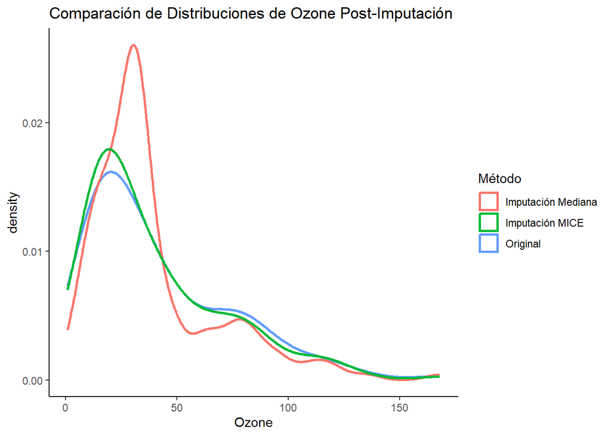

Las distribuciones de probabilidad indican que el método de imputación MICE preserva mejor la forma original de la variable `Ozone`, en comparación con la imputación por mediana.

# 4 Análisis estadístico básico

Estadísticas descriptivas por variable (con datos imputados)

| Variable | Mínimo | Media | Mediana | Máximo | Desv. Estándar |
| --- | --- | --- | --- | --- | --- |
| Ozone | 1.0 | 40.66 | 29.0 | 168.0 | 31.84 |
| Solar.R | 7.0 | 185.12 | 203.0 | 334.0 | 90.63 |
| Wind | 1.7 | 9.96 | 9.7 | 20.7 | 3.52 |
| Temp | 56.0 | 77.88 | 79.0 | 97.0 | 9.47 |

# 5 Visualización de datos

## 5.1 Boxplots para detectar outliers

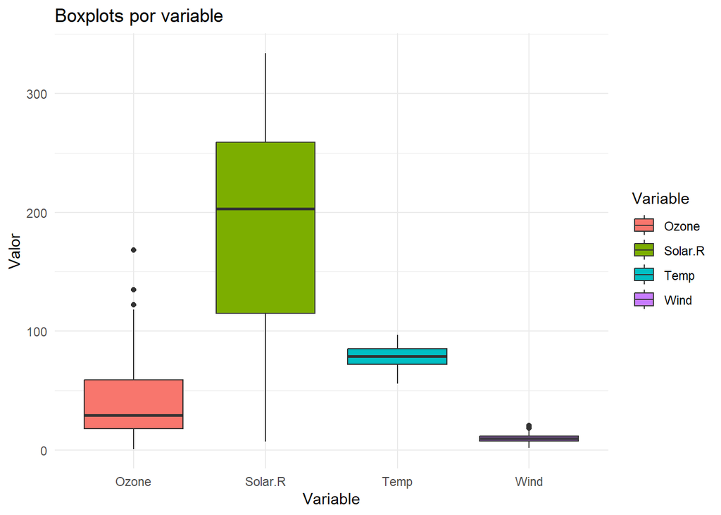

## 5.2 Gráfico de dispersión: Temperatura vs Ozono

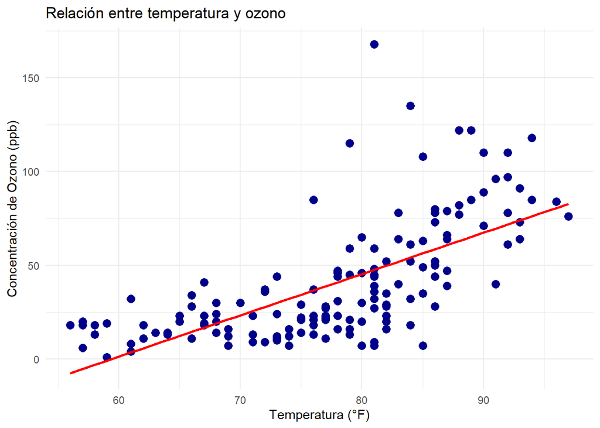

El gráfico muestra una relación positiva entre temperatura y ozono: a mayor temperatura, mayor concentración de ozono.